# IE 582 Project

## Obtaining Data

```python
url = 'https://raw.githubusercontent.com/ozanoztrk/data/main/train.csv'
df = pd.read_csv(url)


url = 'https://raw.githubusercontent.com/ozanoztrk/data/main/test.csv'
df_test = pd.read_csv(url)
```

Some basic functions are defined in appendix.

## INTRODUCTION

This is a machine learning project which aims to find the best evaluation score for a given dataset.

The datasets have two files as training and test data where training data is used for modeling part while test data for evaluation part. These datasets are randomly selected from the original data.

Target variable vector consists of two classes called “a” and “b” whereas feature matrix includes both binary columns and continuous columns. Additionally, there is class imbalance, thus so minimization of error rate for each class should be considered. Area under ROC curve that is an indicator of performance for binary classification problems should be also maximized during model building. Additionally, balanced accuracy is another metric that we need to consider. The evaluation will be based on the average of these two metrics.

This project consist of 3 parts;

- Data Engeering
- Model Selection
- Evaluation.

First, we focus on preprocessing of data including an investigation for outliers in each class, missing values, intensity of class imbalance, feature importance, and feature independence. In order to obtain results for our investigation we involve proximity matrix, boxplots,histograms related to proximity matrix results, heat maps, correlation matrix, and feature importance graphs.

Afterwards, we proceed to build some models that we deeply cover during courses. In that part we strive for using algorithms as much as possible due to the fact that algorithms may outweigh each other in terms of different concepts (for instance gradient boosting mainly focus on low biased structure whereas random forest focus on low variance structure). For regression models, we are so sensitive not to employ whole features to reduce variance or for algorithms which are close to support vector, gradient boosting and random forest concepts we strive for keeping whole feature information as much as possible to get strong learning, also we tune those model's parameters according to having nice accuracy and ROC values. Sometimes there are some cases we can not obtain results for relevant algorithm due to parameters that leads to high complexity, therefore faster training speed algorithms with sufficient efficiency such as light gbm, xgboost are also chosen over other algorithms.

### Explanatory Data Analysis

```python
binary,train_same_value,category,continous=information_table(df)
```

```
Dataset has 2074 instances and 61 features.
Data has 2074 instances.
Class Type is Classification.
Data has 60 numeric and 0 object features.
Features: ['x50', 'x52'] have same values.
Features: ['x2', 'x3', 'x4', 'x12', 'x13', 'x15', 'x16', 'x17', 'x18', 'x19', 'x20', 'x21', 'x22', 'x23', 'x24', 'x25', 'x26', 'x28', 'x29', 'x31', 'x33', 'x34', 'x35', 'x37', 'x38', 'x39', 'x40', 'x41', 'x43', 'x44', 'x45', 'x46', 'x47', 'x48', 'x49', 'x51', 'x53', 'x54', 'x55', 'x56', 'x57', 'x58'…
Binary Features number: 44
Features:['x5', 'x6', 'x7', 'x30'] might be categorical. (Unique values are less than 30)
Features:['x1', 'x8', 'x9', 'x10', 'x11', 'x14', 'x27', 'x32', 'x36', 'x42'] might be continous.
Data has no missing value.
Lets examine imbalance:
      y         y
a  1565  0.754581
b   509  0.245419
```

```python
binary,test_same_value,category,continous=information_table(df_test)
```

```
Dataset has 2073 instances and 61 features.
Data has 2073 instances.
Class Type is No Label.
Data has 60 numeric and 0 object features.
Features: ['x37', 'x52', 'x57'] have same values.
Features: ['x2', 'x3', 'x4', 'x12', 'x13', 'x15', 'x16', 'x17', 'x18', 'x19', 'x20', 'x21', 'x22', 'x23', 'x24', 'x25', 'x26', 'x28', 'x29', 'x31', 'x33', 'x34', 'x35', 'x38', 'x39', 'x40', 'x41', 'x43', 'x44', 'x45', 'x46', 'x47', 'x48', 'x49', 'x50', 'x51', 'x53', 'x54', 'x55', 'x56', 'x58', 'x59'…
Binary Features number: 43
Features:['x5', 'x6', 'x7', 'x30'] might be categorical. (Unique values are less than 30)
Features:['x1', 'x8', 'x9', 'x10', 'x11', 'x14', 'x27', 'x32', 'x36', 'x42'] might be continous.
Data has no missing value.
Lets examine imbalance:
      y    y
?  2073  1.0
```

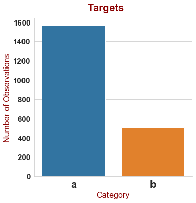

```python
  plot_imbalance(df)
```

```python
same_value=list(set(test_same_value) | set(train_same_value))
same_value
```

```
['x50', 'x52', 'x37', 'x57']
```

These four variables have zero standard deviation thus we removed them from the dataset.

```python
df.drop(columns=same_value,inplace=True)
df_test.drop(columns=same_value,inplace=True)
df_test.drop(columns=['y'],inplace=True)
```

```python
df=binarize_y(df)
```

```python
df.describe()
```

|  | x1 | x2 | x3 | x4 | x5 | x6 | x7 | x8 | x9 | x10 | ... | x49 | x51 | x53 | x54 | x55 | x56 | x58 | x59 | x60 | y |
| --- | --- | --- | --- | --- | --- | --- | --- | --- | --- | --- | --- | --- | --- | --- | --- | --- | --- | --- | --- | --- | --- |
| count | 2074.000000 | 2074.000000 | 2074.000000 | 2074.000000 | 2074.000000 | 2074.000000 | 2074.000000 | 2074.000000 | 2074.000000 | 2074.000000 | ... | 2074.000000 | 2074.000000 | 2074.000000 | 2074.000000 | 2074.000000 | 2074.000000 | 2074.000000 | 2074.000000 | 2074.000000 | 2074.000000 |
| mean | 30.089682 | 0.671167 | 0.662006 | 0.690453 | 9.082932 | 8.990357 | 9.108968 | 30.171649 | 101.248023 | 99.718660 | ... | 0.010125 | 0.105111 | 0.086307 | 0.320154 | 0.017358 | 0.429122 | 0.142237 | 0.006268 | 0.031340 | 0.245419 |
| std | 4.701475 | 0.469903 | 0.473141 | 0.462418 | 5.544789 | 5.608458 | 5.501365 | 5.599208 | 58.263090 | 57.657543 | ... | 0.100138 | 0.306770 | 0.280884 | 0.466648 | 0.130632 | 0.495070 | 0.349378 | 0.078942 | 0.174278 | 0.430439 |
| min | 13.000000 | 0.000000 | 0.000000 | 0.000000 | 0.000000 | 0.000000 | 0.000000 | 13.000000 | 0.100000 | 0.000000 | ... | 0.000000 | 0.000000 | 0.000000 | 0.000000 | 0.000000 | 0.000000 | 0.000000 | 0.000000 | 0.000000 | 0.000000 |
| 25% | 27.000000 | 0.000000 | 0.000000 | 0.000000 | 4.000000 | 4.000000 | 4.000000 | 26.000000 | 49.525000 | 49.200000 | ... | 0.000000 | 0.000000 | 0.000000 | 0.000000 | 0.000000 | 0.000000 | 0.000000 | 0.000000 | 0.000000 | 0.000000 |
| 50% | 30.000000 | 1.000000 | 1.000000 | 1.000000 | 9.000000 | 9.000000 | 9.000000 | 30.000000 | 101.450000 | 99.650000 | ... | 0.000000 | 0.000000 | 0.000000 | 0.000000 | 0.000000 | 0.000000 | 0.000000 | 0.000000 | 0.000000 | 0.000000 |
| 75% | 33.000000 | 1.000000 | 1.000000 | 1.000000 | 14.000000 | 14.000000 | 14.000000 | 34.000000 | 153.300000 | 150.250000 | ... | 0.000000 | 0.000000 | 0.000000 | 1.000000 | 0.000000 | 1.000000 | 0.000000 | 0.000000 | 0.000000 | 0.000000 |
| max | 50.000000 | 1.000000 | 1.000000 | 1.000000 | 18.000000 | 18.000000 | 18.000000 | 49.000000 | 200.000000 | 199.900000 | ... | 1.000000 | 1.000000 | 1.000000 | 1.000000 | 1.000000 | 1.000000 | 1.000000 | 1.000000 | 1.000000 | 1.000000 |

8 rows × 57 columns

#### Data Plots

```python
skewed_features(df,0.5)
```

```
x27     1.179737
x32     0.598003
x36     4.650488
x42    12.055991
dtype: float64
```

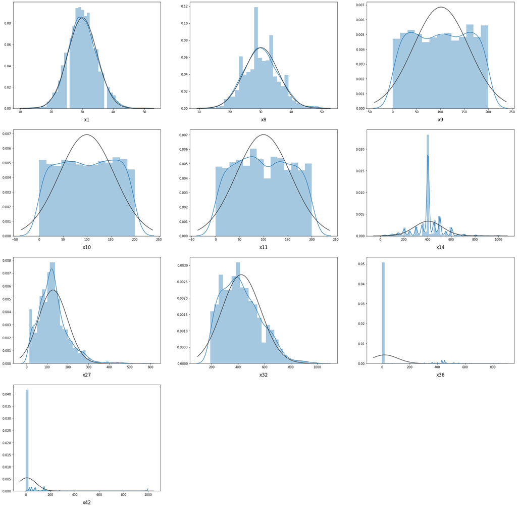

```python
plot_dist(df)
```

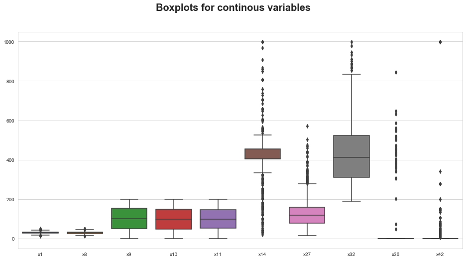

```python
box_plots(df[continous])
```

According to boxplot of continuous features we can observe that most of boxplot structures resemble to boxplot that belongs to perfectly normal distributed data with respect to median and mean equality as well as skewness and symmetry features . Therefore, we can make outlier analysis in line with the formula used in boxplot (such as Q3+1.5*IQR…where 1.5 comes from normal distribution assumption) . Undoubtedly, boxplots give us a nice demonstration whether or not our data is close to normal distribution but can not give any mathematical result of how much our data is close to normal distribution, that means it does not present any significance level for closeness. So it must be confessed that our continuous features may not have normal distribution in real scenario as they seem in boxplots.

#### Correlation Heatmap

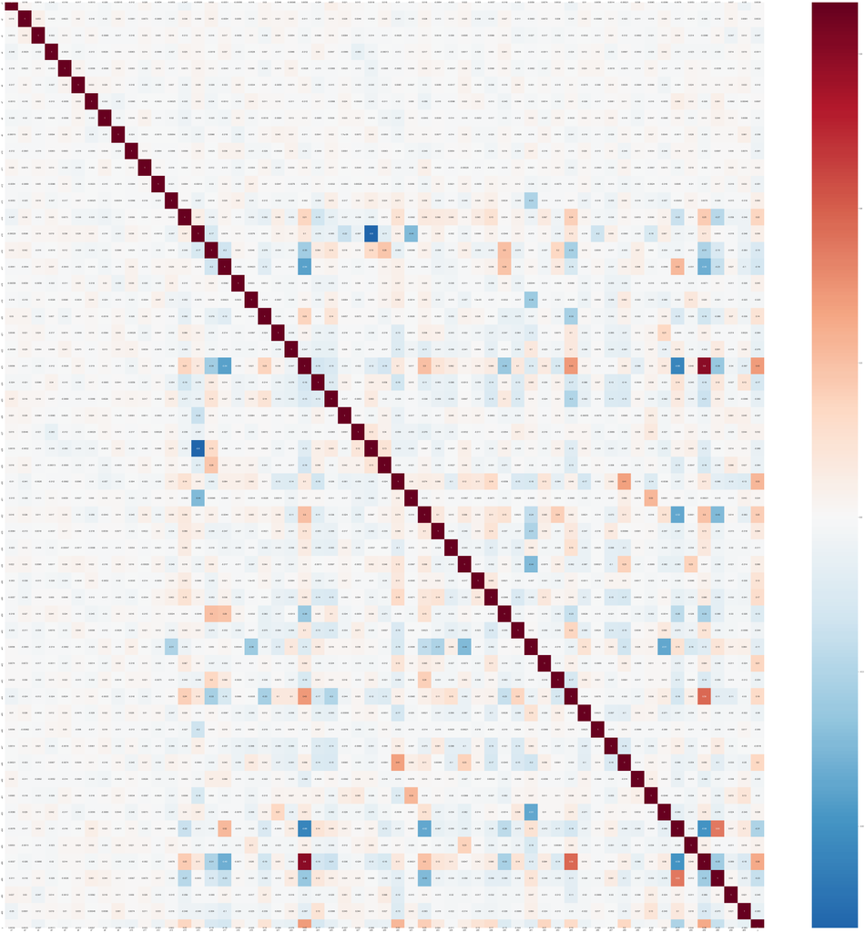

```python
corr_heatmap(df)
```

```python
correlated_pairs(df,0.90)
df=drop_correlated(df, 0.90)
```

```
[]
```

```
[]
```

There is no highly correlated feature(more than %90). We didn't want to remove any feature because we mainly used models which do not include regression.

## RELATED LITERATURE

Page 47, Imbalanced Learning: Foundations, Algorithms, and Applications 2013: Here we embrace the concept of SMOTE and SMOTENC methods to achieve class balance in order to execute our algorithms in much more effective way. Notes during courses: Here we embrace the structures and methods significantly emphasised by our instructor for a given data set.

## APPROACH

Initially one of the biggest issue to what we must pay attention in our case is the class imbalance structure. Therefore we need to turn it into more balanced structure employing preprocessing methods. Imbalanced classification problem is kind of a classification problem where the distribution of instances for classes is biased, so it actually creates a challenge for models with respect to algorithms we learned in courses due to the fact that most of machine learning algorithms including classification were designed according to the assumption of an equal number of instances for each class. This leads to models that have poor predictive performance, especially for the minority class. This situation really poses a problem because the minority class can be ignored and the model has a great potential to make classification errors for the minority class than the majority class. In addition, we may have outliers in each class and if we do not cancel them out then our machine learning algoritms may give more deviated results because employing outliers we force our algorithms to try to predict them which is nonsense actually. According to potential issues we mentioned above, first we check each class whether or not outliers exist involving proximity matrix. Here we set our threshold 0.05, and we find that major class has some outliers whereas minor class has no outliers. Thus deleting outliers in major class results in both having more balanced structure in all data than it had before and having more homogeneity in major class itself.

Afterwards, using SMOTE-NC ( Synthetic Minority Oversampling Technique with Nominal and Continuous Data ) we create synthetic instances for minor class to increase the balanced more in data. Here, employing nearest neighbour computation for minor class we take the convex computation for continuous features whereas for the binary features we take the majority of the k nearest neighbour. After we have reached balanced data in whole data, we again take a glance at outliers using proximity matrix and cancel them out.

Additionally, as an alternative to SMOTE-NC, we generated synthetic data by using proximity matrix.

After we reach balance structure and clean the outliers we do not apply any feature selection because first we aim to employ gradient boosting, random forest, support vector machine. Unlike the regression models, mentioned models are more robust, they do not have much more assumptions(such as error distribution assumption, independency assumption….) also in regression models having lots of features generally leads to low bias high variance or overfitness but in gbm, svm and random forest even we have lots of features we can tune the parameters easily and avoid the overfitness. In short without losing information by not deleting features, we have more easiness and potential to reach nice models for gbm, svm and random forest than regression models.

It must be confessed that algorithms mentioned above are capable of consuming time,energy and memory tremendously for instance support vector algorithm with high penalized constant and low gamma value or gradient boosting with high number trees with low learning rate, so we take light gbm method into account which is working according to leaf based structure instead of level based in decision trees. Thus we can achieve faster training speed and high efficiency, lower memory usage, accuracy as good as gradient boosting at least. In addition to that, xgboost algorithm is capable of having more information about the direction of gradient because of the fact that at each step it is calculating second order gradients to minimise the loss function thus we can train faster and deliver higher performance than gradient boosting algorithm.

### Data Engineering

In this part our main appproach was to create as many different datasets as possible in order to increase the performance. Thus we applied different feature selection techniques, outlier detection methods, scaling techniques and sampling methods.

Our data engineering part consists of two main approaches; Distribution based, Model Based data engineering.

#### Instance Selection

##### Distribution Based

```python
def remove_outlier(df,n=3,m=30):
    cont = [i for i in df.columns if i not in category_features(df,threshold1=m)]
    df1=df[cont].copy()
    df1_mean, df1_std = df1.mean(), df1.std()
    cut_off = df1_std * n
    lower, upper = df1_mean - cut_off, df1_mean + cut_off
    df2=df1[(df1>lower) & (df1<upper)]
    ind=pd.isnull(df2).any(1).nonzero()[0]
    df3=df.index.isin(ind)
    df4=df[~df3].copy()
    return df4.reset_index(drop=True)
```

##### Model Based

```python
def proximityMatrix(model, X, normalize=True):

    terminals = model.apply(X)
    nTrees = terminals.shape[1]

    a = terminals[:,0]
    proxMat = 1*np.equal.outer(a, a)

    for i in range(1, nTrees):
        a = terminals[:,i]
        proxMat += 1*np.equal.outer(a, a)

    if normalize:
        proxMat = proxMat / nTrees

    return proxMat

def proximity_calculation(data):
    ###Before proximity matrix, create syntetic data
    col=len(data.columns)-1
    matrix = np.transpose(np.array(data))
    np.random.permutation(matrix[col])
    permutated = pd.DataFrame()
    for i in range (0,col):
        perm = np.random.permutation(matrix[i])
        permutated[i] = perm

    permutated.columns = data.iloc[:,0:col].columns
    permutated['class'] = np.full(len(data),0)

    ##create copy for original data
    data_copy = data.iloc[:,0:col]
    data_copy['class'] = np.full(len(data),1)

    #concat syntetic and original instances
    data_combined = pd.concat([data_copy,permutated],ignore_index= True)

    inputs = data_combined.iloc[:,0:col]
    target = data_combined.iloc[:,col]
    model = RandomForestClassifier(n_estimators=500, max_features=2, min_samples_leaf=40)
    model.fit(inputs, target)
    prox_matrix = proximityMatrix(model, inputs, normalize=True)
    return prox_matrix,permutated,data_copy,data_combined

def proximity_removed_df(df,threshold=0.05,dist_measure=10,hist=False):

    y=df.iloc[:,-1]
    x=df.drop(columns=[y.name])

    major=df[df['y']==0]

    major_prox, major_perm, major_copy,major_combined = proximity_calculation(data = major)
    ###Just for original data proximity matrix
    major_prox_df = pd.DataFrame(major_prox[0:major.shape[0],0:major.shape[0]])

    ##counting the points that proximity value is less than 0.10
    count = []
    for i in range(0,major.shape[0]):
        count.append(sum(major_prox_df[i] < threshold))

    ##less than 5 are taken
    major_new = major[np.array(count) < dist_measure]

    minor=df[df['y']==1]
    new_df=pd.concat([major_new,minor],axis=0)
    new_df.reset_index(inplace=True,drop=True)
    return new_df
```

#### Feature Selection

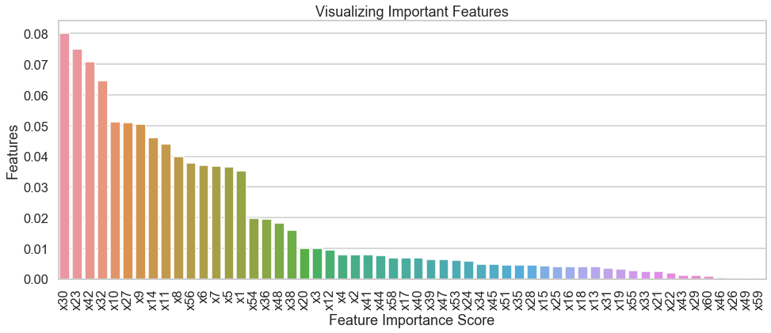

```python
from sklearn.ensemble import RandomForestClassifier
from sklearn.feature_selection import SelectFromModel

def feateare_importance_plot(df):
    y=df.iloc[:,-1]
    x=df.drop(columns=[y.name])

    clf=RandomForestClassifier(n_estimators=100)

    #Train the model using the training sets y_pred=clf.predict(X_test)
    clf.fit(x,y)


    feature_imp = pd.Series(clf.feature_importances_,index=x.columns).sort_values(ascending=False)

    plt.figure(figsize=(16, 6))
    sns.set_context("talk")
    sns.barplot(y = feature_imp, x=feature_imp.index)

    plt.xticks(rotation=90)
    plt.xlabel('Feature Importance Score')
    plt.ylabel('Features')
    plt.title("Visualizing Important Features")
    plt.show()

feateare_importance_plot(df)
```

According to feature importance graph we involve random forest method and calculate total impurity decrease over all trees in random forest, also we take the sum of the impurity decrease in each node over all trees in random forest due to relevant feature and finally we take the proportion of them to get importance values.

```python
def selected_features(df):
    y=df.iloc[:,-1]
    x=df.drop(columns=[y.name])
    sel = SelectFromModel(RandomForestClassifier(n_estimators = 100))
    sel.fit(x, y)
    selected_feat= x.columns[(sel.get_support())]
    return selected_feat

def model_based_df(df,selected_feat):
    y=df.iloc[:,-1]
    x=df[selected_feat]
    return pd.concat([x,y],axis=1)
```

#### Scaling

```python
from sklearn.preprocessing import StandardScaler

def scaling(df,test):
    scaler=StandardScaler()
    if test:
        x=df
        return pd.DataFrame(scaler.fit_transform(x))
    else:
        y=df.iloc[:,-1]
        x=df.drop(columns=[y.name])
        transformed_x=pd.DataFrame(scaler.fit_transform(x))
        return pd.concat([transformed_x,y],axis=1)
```

After several trials, we found that standardscaler yielded better result compare to other scaling methods.

#### Sampling and Data Generation

```python
def proximity_generated_df(df,border=0.4,hist=False):

    y=df.iloc[:,-1]
    x=df.drop(columns=[y.name])

    minor=df[df['y']==1]

    minor_prox, minor_perm, minor_copy,minor_combined = proximity_calculation(data = minor)
    ###Just for original data proximity matrix
    minor_prox_df = pd.DataFrame(minor_prox[0:minor.shape[0],0:minor.shape[0]])

    ###Compare syntetic data and original data
    syntetic_proc = pd.DataFrame(minor_prox[minor.shape[0]:,minor.shape[0]:])
    ##average proximity value
    mean = []
    for i in range(0,minor.shape[0]):
        mean.append(np.mean(syntetic_proc.iloc[i]))
    if hist:
        pd.DataFrame(mean).hist()

    index = np.array(mean) > border
    syntetic = minor_combined.iloc[minor.shape[0]:,0:minor.shape[1]-1]
    syntetic.reset_index(drop=True, inplace=True)
    syntetic = syntetic[index]
    syntetic.reset_index(drop=True, inplace=True)
    syntetic['y'] = np.full(len(syntetic),1)


    final_df = pd.concat([df,syntetic])
    final_df.reset_index(inplace=True,drop=True)
    return final_df
```

```python
from imblearn.over_sampling import SMOTENC

def SMOTENC_sample(df,strategy):
    y=df.iloc[:,-1]
    x=df.drop(columns=[y.name])
    cat_names=category_features(x,20)
    cat_features = [x.columns.get_loc(c) for c in cat_names]
    smote=SMOTENC(sampling_strategy=strategy, categorical_features=cat_features)
    X,Y= smote.fit_resample(x, y)
    return pd.concat([X,Y],axis=1)
```

#### Feature Generation

```python
from sklearn.preprocessing import PolynomialFeatures

def poly_transform(df,test=False):
    poly=PolynomialFeatures(degree=2)

    if test:
        x=df
        x_transformed=pd.DataFrame(poly.fit_transform(x))
    else:
        y=df.iloc[:,-1]
        x=df.drop(columns=[y.name])
        poly_x=pd.DataFrame(poly.fit_transform(x))
        x_transformed=pd.concat([poly_x,y],axis=1)
    return x_transformed
```

#### Main

```python
def main(df,df_test,remove_outliers,proximity_outlier,standard_scale,polynomial_transform,model_based_selection,generate_instance,smote,strategy=0.5,border=0.45):
    if remove_outliers:
        df=remove_outlier(df)

    if proximity_outlier:
        df=proximity_removed_df(df,threshold=0.05,dist_measure=5)

    if standard_scale:
        df=scaling(df,test=False)
        df_test=scaling(df_test,test=True)

    if polynomial_transform:
        df=poly_transform(df,test=False)
        df_test=poly_transform(df_test,test=True)

    if model_based_selection:
        sel_feats=selected_features(df)
        df=model_based_df(df,sel_feats)
        df_test=df_test[sel_feats]

    if generate_instance:
        df=proximity_generated_df(df,border=border)


    if smote:
        df=SMOTENC_sample(df,strategy)


    return df,df_test
```

[figure not shown]

```python
df1,df1_test=main(df,df_test,remove_outliers=False,proximity_outlier=True, standard_scale=False,polynomial_transform=False,model_based_selection=False,generate_instance=True,smote=False)


df2,df2_test=main(df,df_test,remove_outliers=False,proximity_outlier=False,standard_scale=True,polynomial_transform=False,model_based_selection=True,generate_instance=False,smote=True)


df3,df3_test=main(df,df_test,remove_outliers=True,proximity_outlier=False, standard_scale=True,polynomial_transform=False,model_based_selection=False,generate_instance=False,smote=True)
```

### Model Selection

For model selection, we used RandomizedCV method. RandomizedCV is library in sklearn which enables performing k-folds cross validation for given parameters. In this section we defined search spaces for each model. Furthermore, we defined a custom metric which would give us the intended score.

#### LGBM

```python
from sklearn.model_selection import train_test_split
from sklearn.model_selection import RandomizedSearchCV, GridSearchCV

import lightgbm as lgb
import xgboost as xgb

from sklearn.metrics import roc_auc_score, balanced_accuracy_score, make_scorer

from scipy.stats import randint as sp_randint
from scipy.stats import uniform as sp_uniform
```

```python
def lgbm_final_model(df,iter_size,cv):

    y=df.iloc[:,-1]
    x=df.drop(columns=[y.name])

    param_test ={'boosting_type':['gbdt'],
                 'n_estimators':sp_randint(30, 300),
                 'objective':['binary'],
                 'learning_rate':list(np.logspace(np.log10(0.01), np.log10(0.2), base = 10, num = 100)),
                 'num_leaves': sp_randint(6, 50),
                 'min_child_samples': sp_randint(50, 500),
                 'min_child_weight': [1e-5, 1e-3, 1e-2, 1e-1, 1, 1e1, 1e2, 1e3, 1e4],
                 'subsample': sp_uniform(loc=0.2, scale=0.8),
                 'colsample_bytree': sp_uniform(loc=0.4, scale=0.6),
                 'reg_alpha': [0, 1e-1, 1, 2, 5, 7, 10, 50, 100],
                 'reg_lambda': [0, 1e-1, 1, 5, 10, 20, 50, 100]}

    n_HP_points_to_test = iter_size

    clf = lgb.LGBMClassifier(max_depth=-1, random_state=SEED, silent=True, metric='auc', n_jobs=3)

    gs = RandomizedSearchCV(estimator=clf, param_distributions=param_test,
                            n_iter=n_HP_points_to_test,
                            scoring = {'AUC': 'roc_auc',
                                       'BAL': make_scorer(balanced_accuracy_score,greater_is_better=True),
                                       'ROC': make_scorer(roc_auc_score,greater_is_better=True)},
                            cv=cv,
                            refit='AUC',
                            random_state=SEED,
                            verbose=True,
                            n_jobs=-1)


    gs.fit(x, y)

    results=gs.cv_results_


    results['AVR']= (results['mean_test_ROC'] + results['mean_test_BAL'])/2


    i1 = results['AVR'].argmax()

    opt_parameters1=results['params'][i1]

    opt_score=results['AVR'][i1]

    clf_final = lgb.LGBMClassifier(**clf.get_params())

    clf_final.set_params(**opt_parameters1)

    return clf_final,opt_score
```

#### XGBM

```python
def xgbm_final_model(df,iter_size,cv):

    y=df.iloc[:,-1]
    x=df.drop(columns=[y.name])

    param_test ={'boosting_type':['gbtree'],
                 'n_estimators':sp_randint(30, 300),
                 'objective':['binary:logistic'],
                 'max_depth': sp_randint(3, 50),
                 'gamma':[0, 1e-2,1e-1, 1, 2, 5, 7, 10, 50, 100],
                 'learning_rate':list(np.logspace(np.log10(0.01), np.log10(0.2), base = 10, num = 100)),
                 'num_leaves': sp_randint(6, 50),
                 'min_child_samples': sp_randint(50, 500),
                 'min_child_weight': [1e-5, 1e-3, 1e-2, 1e-1, 1, 1e1, 1e2, 1e3, 1e4],
                 'subsample': sp_uniform(loc=0.2, scale=0.8),
                 'colsample_bytree': sp_uniform(loc=0.4, scale=0.6),
                 'reg_alpha': [0, 1e-1, 1, 2, 5, 7, 10, 50, 100],
                 'reg_lambda': [0, 1e-1, 1, 5, 10, 20, 50, 100]}

    n_HP_points_to_test = iter_size

    clf = xgb.XGBClassifier(random_state=SEED, silent=True, metric='auc', n_jobs=3)

    gs = RandomizedSearchCV(estimator=clf, param_distributions=param_test,
                            n_iter=n_HP_points_to_test,
                            scoring = {'AUC': 'roc_auc',
                                       'BAL': make_scorer(balanced_accuracy_score,greater_is_better=True),
                                       'ROC': make_scorer(roc_auc_score,greater_is_better=True)},
                            cv=cv,
                            refit='AUC',
                            random_state=SEED,
                            verbose=True,
                            n_jobs=-1)

    gs.fit(x, y)

    results=gs.cv_results_


    results['AVR']= (results['mean_test_ROC'] + results['mean_test_BAL'])/2


    i1 = results['AVR'].argmax()

    opt_parameters1=results['params'][i1]

    opt_score=results['AVR'][i1]

    clf_final = xgb.XGBClassifier(**clf.get_params())

    clf_final.set_params(**opt_parameters1)

    return clf_final,opt_score
```

#### RF

```python
from sklearn.ensemble import RandomForestClassifier

def rf_final_model(df,iter_size,cv):

    y=df.iloc[:,-1]
    x=df.drop(columns=[y.name])

    param_test={ 'criterion':['gini', 'entropy'],
                 'bootstrap': [True],
                 'max_depth': sp_randint(3, 40),
                 'max_features': [None,'auto', 'sqrt'],
                 'min_samples_leaf': sp_randint(3, 20),
                 'min_samples_split': sp_randint(3,20),
                 'n_estimators': sp_randint(300,2000),
                 'ccp_alpha':list(np.linspace(0,1,30))}

    n_HP_points_to_test = iter_size

    #n_estimators is set to a "large value". The actual number of trees build will depend on early stopping and 5000 define only the absolute maximum
    clf = RandomForestClassifier(random_state=SEED)

    gs = RandomizedSearchCV(estimator=clf, param_distributions=param_test,
                            n_iter=n_HP_points_to_test,
                            scoring = {'AUC': 'roc_auc',
                                       'BAL': make_scorer(balanced_accuracy_score,greater_is_better=True),
                                       'ROC': make_scorer(roc_auc_score,greater_is_better=True)},
                            cv=cv,
                            refit='AUC',
                            random_state=SEED,
                            verbose=True,
                            n_jobs=-1)

    gs.fit(x, y)

    results=gs.cv_results_


    results['AVR']= (results['mean_test_ROC'] + results['mean_test_BAL'])/2


    i1 = results['AVR'].argmax()

    opt_parameters1=results['params'][i1]

    opt_score=results['AVR'][i1]

    clf_final = RandomForestClassifier(**clf.get_params())

    clf_final.set_params(**opt_parameters1)

    return clf_final,opt_score
```

#### PR

```python
from sklearn.linear_model import SGDClassifier

def sgd_final_model(df,cv):

    y=df.iloc[:,-1]
    x=df.drop(columns=[y.name])


    param_test={'loss':['log'],
                'alpha': list(np.logspace(-2, 2,5)),
                'l1_ratio': list(np.linspace(0,1,6))}



    clf=SGDClassifier(random_state=SEED,penalty='elasticnet',max_iter=15000)


    gs = GridSearchCV(estimator=clf,
                                        param_grid=param_test,
                                        scoring={'AUC': 'roc_auc',
                                                        'BAL': make_scorer(balanced_accuracy_score,greater_is_better=True),
                                                        'ROC': make_scorer(roc_auc_score,greater_is_better=True)},
                                        cv=cv,
                                        refit='AUC',
                                        verbose=True,
                                        n_jobs=-1)

    gs.fit(x, y)

    results=gs.cv_results_


    results['AVR']= (results['mean_test_ROC'] + results['mean_test_BAL'])/2


    i1 = results['AVR'].argmax()

    opt_parameters1=results['params'][i1]

    opt_score=results['AVR'][i1]

    clf_final = SGDClassifier(**clf.get_params())
    clf_final.set_params(**opt_parameters1)

    return clf_final,opt_score
```

#### KNN

```python
from sklearn.neighbors import KNeighborsClassifier

def knn_final_model(df,cv):

    y=df.iloc[:,-1]
    x=df.drop(columns=[y.name])


    clf=KNeighborsClassifier()

    param_test={'n_neighbors':[1,3,5],
                    'weights': ['uniform', 'distance'],
                    'p': [1,2]}


    gs = GridSearchCV(estimator=clf,
                                            param_grid=param_test,
                                            scoring={'AUC': 'roc_auc',
                                                            'BAL': make_scorer(balanced_accuracy_score,greater_is_better=True),
                                                            'ROC': make_scorer(roc_auc_score,greater_is_better=True)},
                                            cv=cv,
                                            refit='AUC',
                                            verbose=True,
                                            n_jobs=-1)

    gs.fit(x, y)

    results=gs.cv_results_


    results['AVR']= (results['mean_test_ROC'] + results['mean_test_BAL'])/2


    i1 = results['AVR'].argmax()

    opt_parameters1=results['params'][i1]

    opt_score=results['AVR'][i1]

    clf_final = KNeighborsClassifier(**clf.get_params())

    clf_final.set_params(**opt_parameters1)

    return clf_final, opt_score
```

```python
from sklearn.ensemble import StackingClassifier
from sklearn.linear_model import LogisticRegression

def final_models(df,n_iter):
    LGBM_final,LGBM_average_score=lgbm_final_model(df,n_iter,10)

    XGBM_final,XGBM_average_score=xgbm_final_model(df,n_iter,10)

    RF_final,RF_average_score=rf_final_model(df,n_iter,10)

    SGD_final,SGD_average_score=sgd_final_model(df,10)

    KNN_final,KNN_average_score=knn_final_model(df,10)

    return [LGBM_final,XGBM_final, RF_final,SGD_final, KNN_final],[LGBM_average_score,XGBM_average_score,RF_average_score,SGD_average_score,KNN_average_score]
```

```python
data_list=[df,df1,df2,df3]
test_list=[df_test,df1_test,df2_test,df3_test]
```

```python
results={}
for n,i in enumerate(data_list):

    results.update({'df_'+str(n):final_models(i,400)})
```

[output not shown]

```python
def get_results_df(results):
    dfs=[]
    models=[]
    scores=[]

    for k,v in results.items():
        mdl=v[0]
        for i in mdl:
            name = str(i).split('(')[0]
            models.append(name)
        scr=v[1]
        for i in scr:
            scores.append(i)
            dfs.append(k)

    df=pd.DataFrame({
                     'df': dfs,
                     'model': models,
                     'score': scores
                    })
    return df

results_df=get_results_df(results)
```

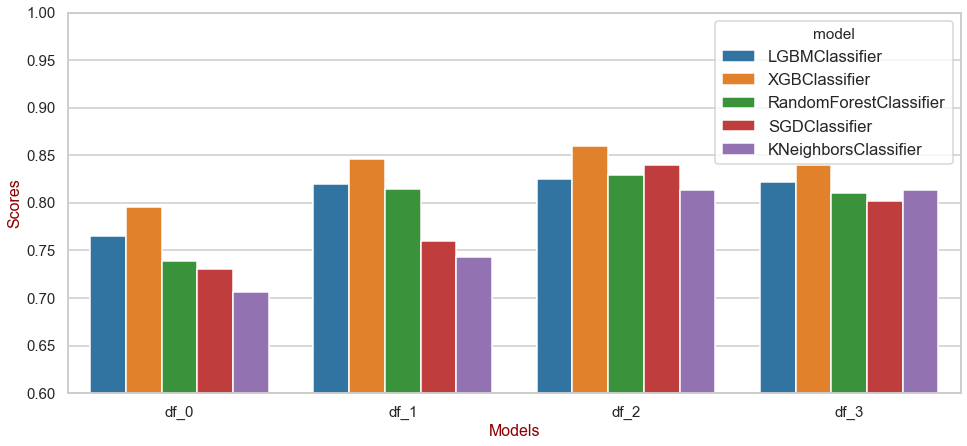

```python
def results_plot(results_df):
    plt.figure(figsize=(16,7))
    sns.set_context("talk")
    sns.set_style('whitegrid')
    sns.barplot(data=results_df, x='df', y='score', hue='model')

    fig.suptitle('Results', y=1.05, size=20, color='darkred')

    plt.ylabel('Scores', size=16, color='darkred')
    plt.xlabel('Models', size=16, color='darkred')
    plt.xticks(size=15)
    plt.yticks(size=15)
    plt.ylim(0.6,1)
    plt.show()

results_plot(results_df)
```

# CONCLUSION and FUTURE WORK

We created multiple dataset which differentiate from each other by their methods of data engineering. Then we applied multiple learning approaches to these datasets. In order to obtain the best performing model, we optimized our learning parameters by tunning it with a custom metric in randomized search with cross validation. This process gave us the average score, which is calculated by the average of ROC AUC and balanced accuracy, for each model belong to each dataset. The graph above shows the scores of different approaches.

The optimal parameter set of xgboost is below;

- 'objective': 'binary:logistic',
- 'use_label_encoder': True,
- 'colsample_bytree': 0.7801178264565368,
- 'gamma': 0,
- 'importance_type': 'gain',
- 'learning_rate': 0.08834940584779542,
- 'max_depth': 8,
- 'min_child_weight': 0.01,
- 'missing': nan,
- 'n_estimators': 177,
- 'reg_alpha': 1,
- 'reg_lambda': 0.1,
- 'subsample': 0.6096744466394248,
- 'boosting_type': 'gbtree',
- 'min_child_samples': 398,
- 'num_leaves': 41

Undoubtedly, there are many methods and algorithms to enhance the accuracy and ROC value further. For instance: After feature selection via feature importance graph, group lasso can be employed where we can create groups using binary features combination regarding to design matrix and can assign continuous features to them and we can examine each group separately for continuous features just solving minimised squared error with relevant constraints, or ANCOVA logistic regression can be employed where we can create design matrix having different coefficients for different groups with respect to continuous data and can optimize log likelihood structure including logit function thus can examine each group separately, or model based regression trees can be employed where splits are chosen with just selected binary features and for the terminal nodes we apply regression models. In addition, without any feature selection at the beginning, stepwise regression models can be employed where we can eliminate features or eliminate grouping effect according to significance levels of parameters (such as p-values…) or maximum log likelihood ratio test.

# APPENDIX

```python
import pandas as pd
import numpy as np
import matplotlib.pyplot as plt
import seaborn as sns
import os


from IPython.core.interactiveshell import InteractiveShell
InteractiveShell.ast_node_interactivity = "all"

import warnings
warnings.simplefilter(action='ignore', category=FutureWarning)
warnings.filterwarnings('ignore')

import random

def seed_everything(seed=0):
    random.seed(seed)
    os.environ['PYTHONHASHSEED'] = str(seed)
    np.random.seed(seed)

SEED=42
seed_everything(SEED)
```

```python
def object_features(df):
    return list(df.loc[:,df.dtypes=='object'].columns)

def numeric_features(df):
    return list(df.loc[:,(df.dtypes=='int64')|(df.dtypes=='float64')].columns)


def category_features(df,threshold1,threshold2=0):
    category_features = []
    for each in df.columns:
        if threshold2 < df[each].nunique() < threshold1:
            category_features.append(each)
    return category_features

def check_type(y):
    try:
        condition=y.nunique()
    except:
        condition=len(np.unique(y))
    if condition==1:
        return 'No Label'
    elif condition==2:
        return 'Classification'
    elif 2<condition<10:
        return 'Multi-Class Classification'
    else:
        return 'Regression'

def check_imbalance(y):
    if check_type(y)!='Regression':
        return pd.concat([y.value_counts(),y.value_counts(normalize=True)],axis=1)

def check_missing_value(df):
    return any(df.isna().sum()!=0)

def get_y(df):
    return df.iloc[:,-1]

def get_x(df):
    return df.iloc[:,:-1]

def information_table(df):
    number_instance = df.shape[0]
    number_feature  = df.shape[1]

    y=df.iloc[:,-1]
    x=df.iloc[:,:-1]

    instance = x.shape[0]

    y_type = check_type(y)

    number_numeric  = len(numeric_features(x))
    number_object   = len(object_features(x))

    missing_value = check_missing_value(x)

    imbalance = check_imbalance(y)

    same_value = category_features(x,2)

    binary = category_features(x,3,1)

    category = category_features(x,30,3)

    continous = [i for i in x.columns if i not in category_features(x,30)]

    print('Dataset has ' + str(number_instance) + ' instances and ' + str(number_feature) + ' features.')
    print('Data has ' + str(instance) + ' instances.')
    print('Class Type is ' + y_type +'.')
    print('Data has ' + str(number_numeric) + ' numeric and ' + str(number_object) + ' object features.')
    print('Features: ' + str(same_value) + ' have same values.')
    print('Features: ' + str(binary) + ' are binary.')
    print('Binary Features number: ' + str(len(binary)))

    print('Features:' +str(category_features(x,30,3)) + ' might be categorical. (Unique values are less than 30)')

    print('Features:' +str(continous) + ' might be continous.')
    if missing_value:
        print('Data has missing value.')
    else:
        print('Data has no missing value.')
    if y_type != 'Regression':
        print('Lets examine imbalance:')
        print(imbalance)
    else:
        plt.hist(y)
        plt.title('Histogram ' + y.name)

    return binary,same_value,category,continous

from sklearn.preprocessing import LabelBinarizer
def binarize_y(df):
    lb=LabelBinarizer()
    y=lb.fit_transform(get_y(df))
    df['y']=y
    return df

def plot_imbalance(df):
    sns.set_style('whitegrid')
    g = sns.catplot(x="y",
                data=df,
                kind="count")
    g.fig.suptitle('Targets', y=1.05, size=20, weight='bold', color='darkred')

    plt.ylabel('Number of Observations', size=16, color='darkred')
    plt.xlabel('Category', size=16, color='darkred')
    plt.xticks(size=20, weight= 'bold')
    plt.yticks(size=15, weight= 'bold')

    plt.show()

from scipy.stats import norm

def plot_dist(df,n=30):
    cont = [i for i in df.columns if i not in category_features(df,threshold1=n)]
    fig, axs = plt.subplots(ncols=2, nrows=0, figsize=(12, 30))
    plt.subplots_adjust(right=2)
    plt.subplots_adjust(top=2)
    sns.color_palette("husl", 8)
    for i, feature in enumerate(list(df[cont]), 1):
        plt.subplot(len(list(cont)), 3, i)
        sns.distplot(df[feature],fit=norm)

        plt.xlabel('{}'.format(feature), size=15,labelpad=12.5)

    return plt.show()

def skewed_features(df,threshold,n=30):
    cont = [i for i in df.columns if i not in category_features(df,threshold1=n)]
    skew=df[cont].skew().abs()
    return skew[skew>threshold]


def box_plots(df):
    fig, ax = plt.subplots(figsize=(16,8))
    fig.suptitle('Boxplots for continous variables',size=20, weight='bold')
    ax = sns.boxplot(data=df)
    plt.show()

def corr_heatmap(df):
    fig, ax =plt.subplots(figsize=(80,80))
    ax = sns.heatmap(df.corr(), cmap='RdBu_r', annot=True, center=0.0)
    plt.show()

def correlated_pairs(df,threshold):
    corr=df.corr()
    indices = np.where(corr > threshold)
    indices = [(corr.index[x], corr.columns[y]) for x, y in zip(*indices) if x != y and x < y]
    return indices



def drop_correlated(df,threshold):
    corr_matrix = df.corr().abs()
    upper = corr_matrix.where(np.triu(np.ones(corr_matrix.shape), k=1).astype(np.bool))

    to_drop = [column for column in upper.columns if any(upper[column] > threshold)]
    print(to_drop)
    return df.drop(to_drop, axis=1)
```

```python
from sklearn.preprocessing import StandardScaler,MinMaxScaler,RobustScaler,QuantileTransformer,Normalizer




def merge_dicts(*dict_args):
    result = {}
    for dictionary in dict_args:
        result.update(dictionary)
    return result

def get_cont(df,n=30):
    cont = [i for i in df.columns if i not in category_features(df,threshold1=n)]
    return df[cont]

def get_n_cont(df,n=30):
    n_cont = [i for i in df.columns if i  in category_features(df,threshold1=n)]
    return df[n_cont]

def combine(df1,df2):
    return pd.concat([df1,df2], axis=1)


def multiple_scale(df,scalers,outlier=False):
    if outlier:
        return {k+'_outlier':combine(pd.DataFrame(v.fit_transform(get_cont(df))),get_n_cont(df)) for k,v in scalers.items()}
    else:
        return {k:combine(pd.DataFrame(v.fit_transform(get_cont(df))),get_n_cont(df)) for k,v in scalers.items()}

def apply_multiple_scale(df,scalers,test=False):
    df1=drop_correlated(df,0.92) #manuel test
    scaled_dfs1=multiple_scale(df1,scalers) #teste uygula

    df1=drop_correlated(df,0.92) #manuel test
    if test:
        df2=df1
    else:
        df2=remove_outlier(df1)
    scaled_dfs2=multiple_scale(df2,scalers,True) #teste uygula

    scaled_dfs=merge_dicts(scaled_dfs1,scaled_dfs2)
    return scaled_dfs
```

```python
from sklearn.preprocessing import PolynomialFeatures


def perform_poly(scaled_train,scaled_test):
    poly=PolynomialFeatures(degree=2)
    transformed_train={}
    for k,v in scaled_train.items():
        x=get_x(v)
        poly_x=pd.DataFrame(poly.fit_transform(x))
        x_transformed=pd.concat([poly_x,get_y(v)],axis=1)
        transformed_train.update({k:v})
        transformed_train.update({str(k)+'_poly':x_transformed})
    transformed_test={}
    for k,v in scaled_test.items():
        test=v
        poly_test=poly.fit_transform(test)
        test_transformed=pd.DataFrame(poly_test)
        transformed_test.update({k:v})
        transformed_test.update({str(k)+'_poly':test_transformed})
    return transformed_train,transformed_test
```

```python
def train_test(df,size=0.25,random_state=SEED):
    y=df.iloc[:,-1]
    x=df.drop(columns=[y.name])
    x_train, x_test, y_train, y_test = train_test_split(x, y, test_size=size, random_state=random_state, stratify=y)
    return x_train, x_test, y_train, y_test
```